# Distribution of Public Service of Canada Employees by Designated Group and Age Range

## checking if our r is working

```r
print("Hello R world")
```

```
## [1] "Hello R world"
```

## Analysis of Table 6

### we are loading required libraries

Loading required libraries

```r
#install.packages(c("readxl", "dplyr", "ggplot2", "tidyr"))
library(readxl)
library(janitor)
library(dplyr)
library(ggplot2)
library(tidyr)
```

### loading the data and cleaning the names

we also cleaned the data to use numbers only, excluding the percentages

```r
library(readxl)
tab06_eng <- read_excel("~/Documents/assignments/keira/cleaned/tab06-eng.xls", skip = 4, n_max = 7)
Sys.setlocale(category = "LC_CTYPE", locale = "en_US.UTF-8")
```

```
## [1] "en_US.UTF-8"
```

```r
tab06_eng <- clean_names(tab06_eng)
print(colnames(tab06_eng))
```

```
##  [1] "age_range"                           "all_employees"
##  [3] "x3"                                  "women"
##  [5] "x5"                                  "x6"
##  [7] "aboriginal_peoples"                  "x8"
##  [9] "x9"                                  "persons_with_disabilities"
## [11] "x11"                                 "x12"
## [13] "members_of_a_visible_minority_group" "x14"
## [15] "x15"
```

```r
selected_colnames <- c("age_range", "all_employees", "women", "members_of_a_visible_minority_group","persons_with_disabilities" , "aboriginal_peoples")
subset_data <- tab06_eng[, selected_colnames]
subset_data <- subset_data[complete.cases(tab06_eng$age_range), ]
head(subset_data)
```

| age_range | all_employees | women | members_of_a_visible_minority_group | persons_with_disabilities | aboriginal_peoples |
| --- | --- | --- | --- | --- | --- |
| Under 35 | 33830 | 18755 | 5599 | 871 | 1515 |
| 35 to 39 | 26338 | 14740 | 4221 | 1009 | 1359 |
| 40 to 44 | 27032 | 15030 | 3957 | 1317 | 1638 |
| 45 to 49 | 28931 | 15971 | 3695 | 1758 | 1742 |
| 50 to 54 | 32710 | 17723 | 3065 | 2476 | 1556 |
| 55 and over | 32515 | 15859 | 3382 | 2959 | 1429 |

### visualization of the data

1. Drawing a bar graph showing the different distributions of employees against their age ranges
1. Converted the data to numerical data
2. Created a bar graph

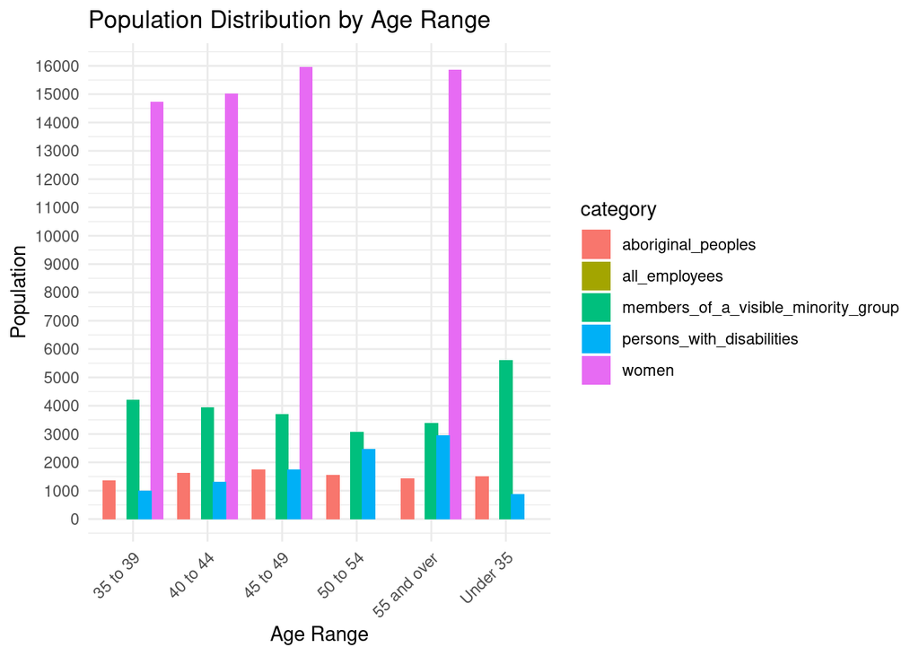

```r
subset_data <- subset_data %>%
  mutate_at(vars(all_employees, women, members_of_a_visible_minority_group, persons_with_disabilities, aboriginal_peoples),
            as.numeric)

subset_data_long <- subset_data %>%
  gather(key = "category", value = "value", -age_range)

ggplot(subset_data_long, aes(x = age_range, y = value, fill = category)) +
  geom_bar(stat = "identity", position = position_dodge(width = 0.8)) +
  labs(title = "Population Distribution by Age Range",
       y = "Population", x = "Age Range") +
  theme_minimal() +
  theme(axis.text.x = element_text(angle = 45, hjust = 1)) +
  scale_y_continuous(limits = c(0, 16000), breaks = seq(0, 16000, by = 1000))
```

from the bar graph above you can see:

- Aboriginal groups are average across the age ranges
- women display a high number across the different ranges
1. distribution of age across populations

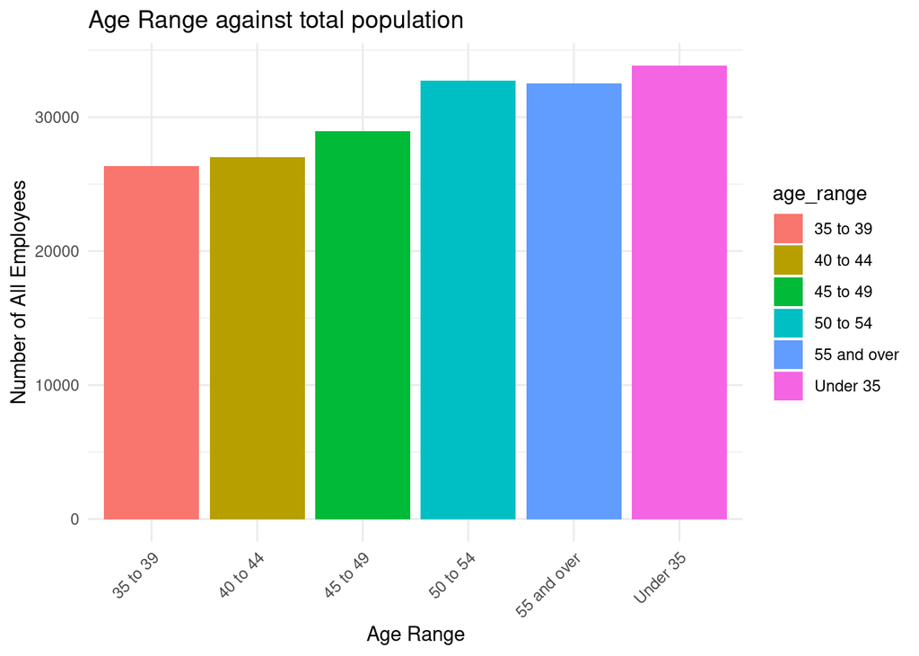

```r
ggplot(subset_data, aes(x = age_range, y = all_employees, fill = age_range)) +
  geom_bar(stat = "identity") +
  labs(title = "Age Range against total population",
       x = "Age Range",
       y = "Number of All Employees") +
  theme_minimal() +
  theme(axis.text.x = element_text(angle = 45, hjust = 1))
```

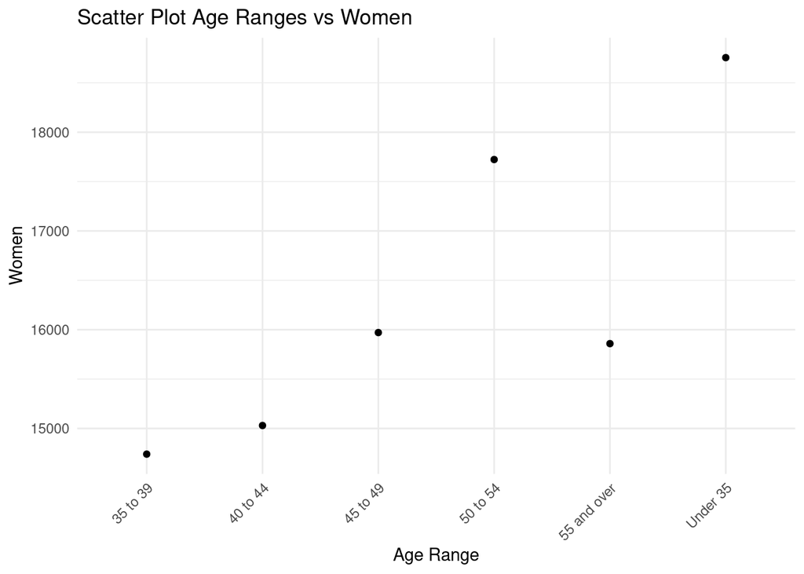

```r
ggplot(subset_data, aes(x = age_range, y = women)) +
  geom_point() +
  labs(title = "Scatter Plot Age Ranges vs Women",
       x = "Age Range",
       y = "Women") +
  theme_minimal() + theme(axis.text.x = element_text(angle = 45, hjust = 1))
```

from the scatter plot above we can deduce:

- women under the age of 35 is highly represented
- there is a few representation of women between the age of 35-39
3. summary of how the employees are spread out

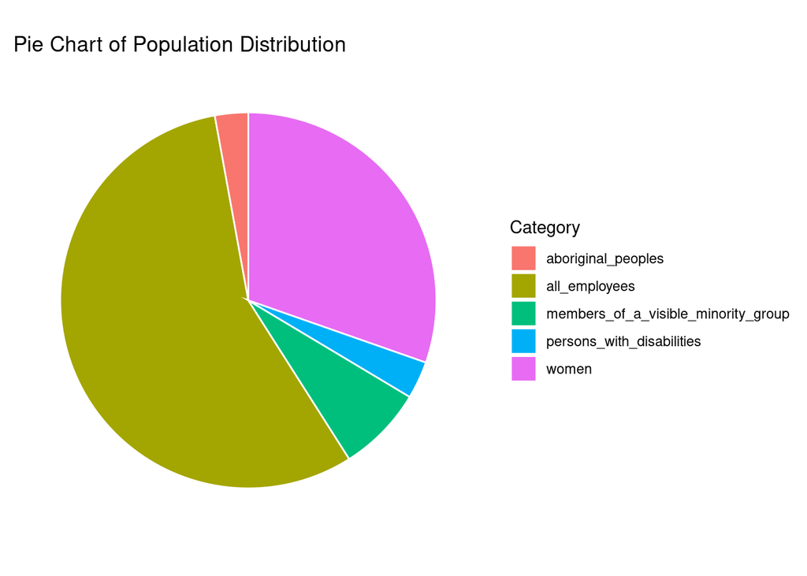

```r
summary_data <- subset_data %>%
  summarise(
    all_employees = sum(all_employees),
    women = sum(women),
    members_of_a_visible_minority_group = sum(members_of_a_visible_minority_group),
    persons_with_disabilities = sum(persons_with_disabilities),
    aboriginal_peoples = sum(aboriginal_peoples)
  )
summary_data_long <- gather(summary_data, key = "category", value = "value")
ggplot(summary_data_long, aes(x = "", y = value, fill = category)) +
  geom_bar(stat = "identity", width = 1, color = "white") +
  coord_polar("y") +
  labs(title = "Pie Chart of Population Distribution",
       fill = "Category") +
  theme_minimal() +
  theme(axis.text = element_blank(),
        axis.title = element_blank(),
        panel.grid = element_blank())
```

from the pie chart above we can deduce:

- women are the second most employed category
- Aborginal people and person with disabilities have a few representation in the job industry